# Practical Machine Learning Assignment

Soren Heitmann

Thursday, April 23, 2015

# Summary

This analysis examines data collected as part of the Human Activity Recognition (HAR) study, presented here: http://groupware.les.inf.puc-rio.br/public/papers/2013.Velloso.QAR-WLE.pdf The study has asked participants to lift a dumbbell weight in five characteristic manners: (A) Correctly, according to proper weigh lifting criteria (B) Throwing elbows forward (C) Lifting dumbbell half-way (D) Lowering dumbbell half-way (E) Throwing the hips forward. Participants performed 10 reps for each activity, while activity monitors were recording their movements in four measurement points: at the belt, on the glove, on the forearm, and on the bumbbell itself. The analysis uses machine learning algorithms to attempt to classify and predict which characteristic movement the participant has performed, according to classifications A-E. This analysis performs a similar predictive classification analysis, with a specific objective of properly classifying a hold-out dataset to meet course assignment criteria.

# Partitioning the Data

As a first step, the data is partitioned into training and test datasets. Here, as a component of the course assignment, the data has already been pre-partitioned and is imported into R as separate data files:

```r
training <- read.csv(file="pml-training.csv",stringsAsFactors=T,header=TRUE)
testing <- read.csv(file="pml-testing.csv",stringsAsFactors=T,header=TRUE)
inValidate <- createDataPartition(training$classe, p=1/20, list=F )
```

Noting that the pre-defined testing dataset has obfuscated the outcome variable, classe, which defined the activity classification of the given participant, a validation dataset is also useful to help train and validate the predictive model. In this case, as the sample size is quite large at 19,622 observations, the validation dataset is established at a small of but adequate size of 5%.

# Exploratory Analysis & Feature Selection

The data taken from the original study includes some pre-processing conducted by the original analysts. In this case, the analysts have use a time-based windowing approach to construct summary statistics for the given window period, such as the overall mean, variance, etc of the measurements in a given time period of a few milliseconds. Consequently, for all time periods outside the designated windowing moment, all summary statistics are NA.

NA values may be of predictive value, in principle; it may characteristically identify when data cannot be collected, for example, which could be informative. In this case, these values are introduced as part of the pre-processing methodology and are systematically introduced. Therefore, we understand that all calculated summary statistics data is not colelcted through the measurements directly, nor available consistnetly throughout the dataset. All columns containing summary statistics will not be good predictors and are thus removed categorically as a process of feature selection by identifying those columns that are entirely NA data in the pre-defined testing dataset. Before doing so, this analysis also performs some pre-processing, by unifying the multi-part raw timestamp columns into a single timestamp value.

```r
training$raw_timestamp <- (training$raw_timestamp_part_1*1000000)+training$raw_timestamp_part_2
testing$raw_timestamp <- (testing$raw_timestamp_part_1*1000000)+testing$raw_timestamp_part_2

na_data <- apply(testing,2,FUN=function(x) { sum(is.na(x)) })
use_cols <- names(na_data)[na_data==0]
use_cols <- intersect(use_cols,intersect(names(training),names(testing)))
train <- training[,c(use_cols,setdiff(names(training),names(testing)))]
test <- testing[,c(use_cols,setdiff(names(testing),names(training)))]
```

Further exploratory analysis can then be conducted by examining the data itself. Before doing so, the data are split into the final training and validation datasets.

```r
valid <- train[ inValidate,]
train <- train[-inValidate,]
```

Given that each activity monitor records a variety of data for each moment of moment, there’s likely to be significant correlation within each monitor type. A feature plot is constructed for each measurement type, below given as example for “belt”, including the “classe” variable

```r
belt_cols <- grep("belt",names(train))
```

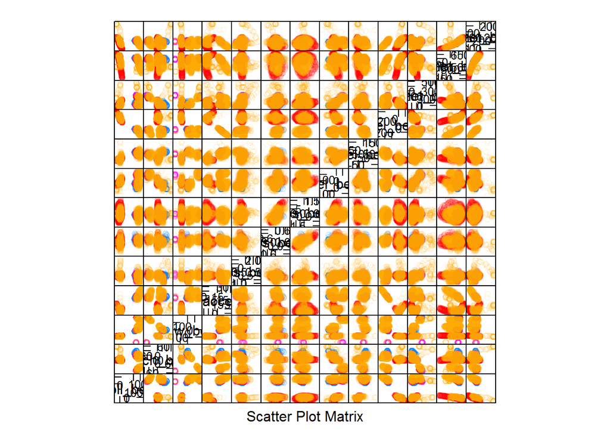

```r
featurePlot(x=train[,belt_cols],y=train$classe,plot="pairs",alpha=.1)
```

The plot is quite dense, but enlarging and exmining the relationships does indeed show significant correlation among the possible predictors. An analysis for the other measurement points shows a similar relationship. As high correlation may dillute the feature classification as the model can split on multiple similar correlated variables, filtering the data to reduce correlation is a major component of feature selection. This is done by creating a correlation matrix and eliminating highly correlated variables by first selecting the most correlated variable against all others, whereupon those variables against which have a 70% or higher correlation are eliminated; this is done for each variable. The matricies are constructed for each measusrement type as follows and eliminated using a manual identification process:

```r
cor(train[,belt_cols])
```

```r
coa = c("classe","accel_arm_y","yaw_belt","accel_forearm_x","accel_dumbbell_z","gyros_arm_z","gyros_belt_y","magnet_dumbbell_z","roll_arm",
        "gyros_forearm_x","magnet_forearm_z","magnet_dumbbell_x","accel_dumbbell_y","accel_dumbbell_x","pitch_forearm","accel_forearm_z",
        "yaw_forearm","gyros_belt_z","yaw_arm","roll_forearm","magnet_belt_y","accel_forearm_y","magnet_forearm_x","magnet_arm_x","total_accel_arm",
        "total_accel_forearm","magnet_arm_z","pitch_arm","gyros_dumbbell_y","gyros_arm_y","gyros_forearm_y")
```

# Model 1: RPart

As an initial classificaiton, a RPart (Recursive Partitioning and Regression Trees) model is used. A cross-validation bootstrapping process is used. Noting that the data collection methodology is highly correlated in time, it is expected that there are biases especially in the early and late stages of the activity – such as the participat picking up the dumbbell and getting started, or a characteristically different final rep as they end the 10 reps. Therefore, a cross validation approach such as k-folds was considered possibly biased for low values of k (large cross validation groups). Cross validation is performed interanally by the caret package, but it may be specified or tuned using the trainControl() call. In this analysis, the trainControl() is specified as below in order to execute the discussed cross validation approach.

```r
cv_rpart <- trainControl(method="boot",number=25,repeats=2)
system.time(rpartmodel<-train(classe ~ .,method="rpart",data=train[,coa], trControl=cv_rpart))
```

```
##    user  system elapsed
##   57.50    0.23   59.69
```

```r
rpartpredict <- predict(rpartmodel$finalModel,newdata=valid[,coa])
rpartpredictions <- unlist(attributes(rpartpredict)$dimnames[2])[apply(rpartpredict,1,FUN=function(x) { match(max(x),x) })]
confusionMatrix(factor(rpartpredictions,levels=levels(valid$classe)),valid$classe)
```

```
## Confusion Matrix and Statistics
##
##           Reference
## Prediction   A   B   C   D   E
##          A 211  49  13  10  13
##          B   7  75   7  12  37
##          C  58  49 140  75  47
##          D   3  16  12  47   1
##          E   0   1   0  17  83
##
## Overall Statistics
##
##                Accuracy : 0.5656
##                  95% CI : (0.534, 0.5969)
##     No Information Rate : 0.2838
##     P-Value [Acc > NIR] : < 2.2e-16
##
##                   Kappa : 0.4499
##  Mcnemar's Test P-Value : < 2.2e-16
##
## Statistics by Class:
##
##                      Class: A Class: B Class: C Class: D Class: E
## Sensitivity            0.7563   0.3947   0.8140  0.29193  0.45856
## Specificity            0.8793   0.9206   0.7176  0.96107  0.97756
## Pos Pred Value         0.7128   0.5435   0.3794  0.59494  0.82178
## Neg Pred Value         0.9010   0.8639   0.9479  0.87389  0.88889
## Prevalence             0.2838   0.1933   0.1750  0.16378  0.18413
## Detection Rate         0.2146   0.0763   0.1424  0.04781  0.08444
## Detection Prevalence   0.3011   0.1404   0.3754  0.08037  0.10275
## Balanced Accuracy      0.8178   0.6576   0.7658  0.62650  0.71806
```

Tested for accuracy against the validation dataset, the RPart model is terrible, with an out of sample accuracy of 56% (although it’s surprisingly a bit higher than the in-sample accuracy of only 55%!).

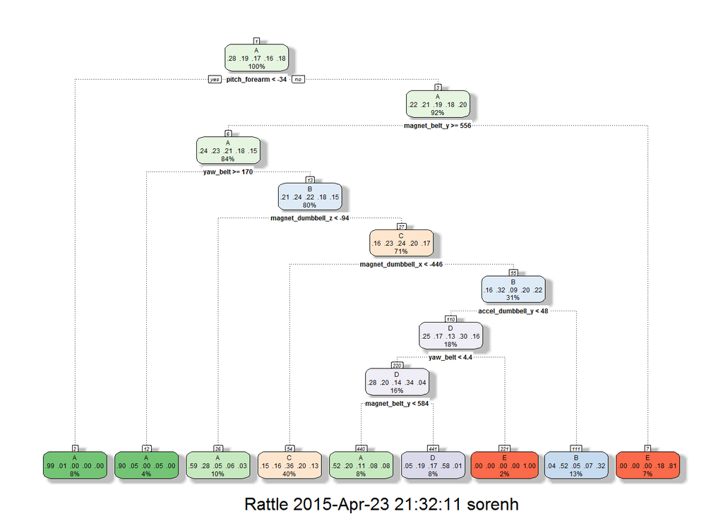

```r
fancyRpartPlot(rpartmodel$finalModel)
```

# Model 2: Random Forest

A random forest is selected to improve on the rpart model. Here, an Out-of-Bag cross-validation methodology is used, as its application is particularly useful for random forests and provides strong bias vs variance trade offs. Once again, cross-validation is handled internally by the caret R package, and is specified by passing the specification in trainControl()

```r
cv_rf <- trainControl(method="oob",number=10,repeats=5,p=0.75)
system.time(rfm <- train(classe ~ ., method="rf", data=train[,coa], trControl=cv_rf))
```

```
##    user  system elapsed
##  167.85    1.07  171.32
```

```r
rfpredict_in <- predict(rfm$finalModel,newdata=train[,coa])
rfpredict_out <- predict(rfm$finalModel,newdata=valid[,coa])

confusionMatrix(rfpredict_in,train$classe)$overall["Accuracy"]
```

```
## Accuracy
##        1
```

```r
confusionMatrix(rfpredict_out,valid$classe)$overall["Accuracy"]
```

```
##  Accuracy
## 0.9989827
```